# Análisis químico-sensorial de la calidad del whisky chileno

## 4.3 Comparación final entre escenarios

| escenario | tipo_escenario | modelo_recomendado | mae_bootstrap | mae_p05 | mae_p95 | rmse_bootstrap | r2_bootstrap | spearman_bootstrap | estabilidad_error | recomendacion_uso | lectura_escenario |
| --- | --- | --- | --- | --- | --- | --- | --- | --- | --- | --- | --- |
| M_pura | principal_real | random_forest_restringido | 0.3958918 | 0.1815655 | 0.6724122 | 0.4584317 | 0.2472768 | 0.1964191 | media | modelo_principal_predictivo | Escenario principal con datos quimico-sensoriales reales (sin cata individual JU). Es la base central para conclusiones predictivas. |
| M_cata_individual | sensibilidad_con_ju | random_forest_restringido | 0.5149154 | 0.2392262 | 0.8911657 | 0.6472388 | 0.6472861 | 0.6893026 | baja | comparacion_con_aporte_ju | Matriz pura mas la cata individual JU agregada. Permite evaluar el aporte y la heterogeneidad introducida por JU, comparando directamente contra M_pura. |
| M_expandida_evaluador | complementario_evaluador | random_forest_restringido | 0.8225619 | 0.6269890 | 1.1251350 | 0.9957123 | 0.1087074 | 0.0978423 | media | complementario_no_principal | Escenario complementario para variabilidad entre evaluadores. No debe interpretarse como aumento independiente de muestras quimicas. |
| M_ia_exploratoria | exploratorio_ia | gradient_boosting_restringido | 0.6015588 | 0.3701306 | 0.9039945 | 0.7026570 | 0.5102545 | 0.7082146 | baja | exploratorio_sintetico_no_real | Escenario sintetico exploratorio con imputacion sensorial asistida por IA. No reemplaza cata real. |

** 01_modelamiento_mae_bootstrap_y_fenolico **

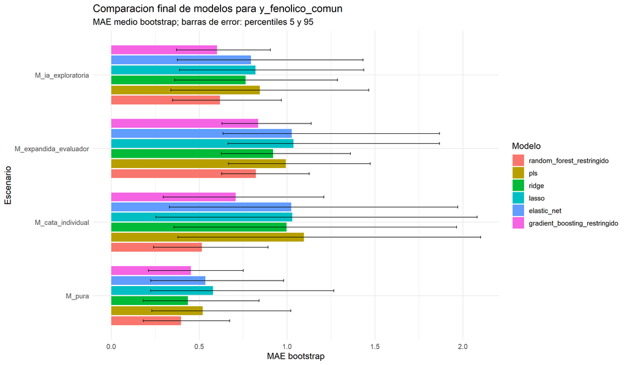

** 02_modelamiento_mejor_modelo_por_escenario **

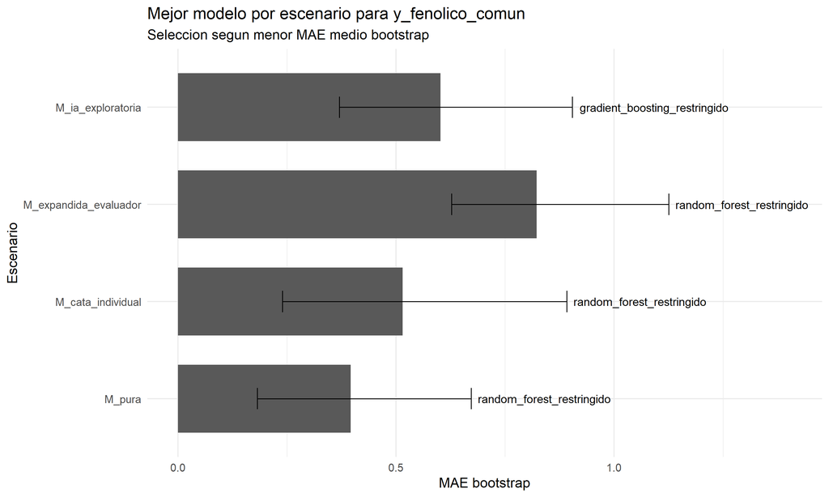

** 03_modelamiento_base_vs_mejor_y_fenolico **

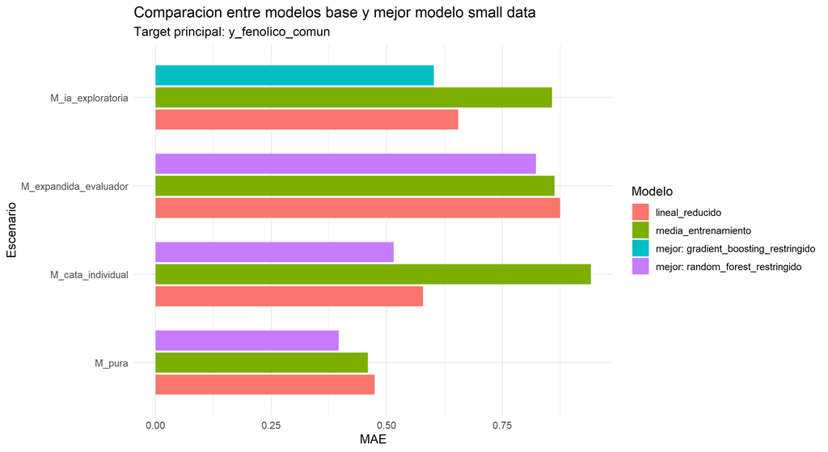

** 04_modelamiento_variables_discusion **

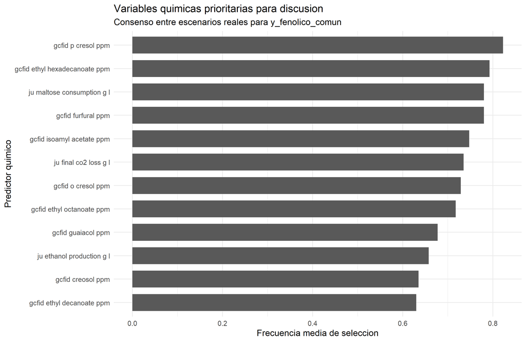

| escenario | target | predictor | predictor_limpio | tecnica | familia_quimica | coherencia_target | n_modelos_con_variable | modelos_que_la_reportan | frecuencia_media | frecuencia_max | importancia_norm_media | importancia_norm_max | n_bootstrap_total_modelos | justificacion_quimica | importancia_norm_minmax | score_combinado | estabilidad_consenso | prioridad_tesis | ranking_consenso | orden_escenario | lectura_final |
| --- | --- | --- | --- | --- | --- | --- | --- | --- | --- | --- | --- | --- | --- | --- | --- | --- | --- | --- | --- | --- | --- |
| M_pura | y_fenolico_comun | x_gcfid_o_cresol_ppm | gcfid o cresol ppm | GC-FID | fenoles_volatiles | alta_directa | 4 | elastic_net; lasso; random_forest_restringido; ridge | 0.7150 | 0.98 | 28.440760 | 44.112582 | 286 | Coherente: cresoles, guaiacol u otros fenoles volatiles se relacionan directamente con notas fenolicas/ahumadas. | 0.7530590 | 0.7340295 | alta | prioritaria | 1 | 1 | variable_prioritaria_directa |
| M_pura | y_fenolico_comun | x_gcfid_p_cresol_ppm | gcfid p cresol ppm | GC-FID | fenoles_volatiles | alta_directa | 4 | elastic_net; lasso; random_forest_restringido; ridge | 0.8225 | 1.00 | 18.559596 | 26.975101 | 329 | Coherente: cresoles, guaiacol u otros fenoles volatiles se relacionan directamente con notas fenolicas/ahumadas. | 0.4615626 | 0.6420313 | alta | prioritaria | 2 | 1 | variable_prioritaria_directa |
| M_pura | y_fenolico_comun | x_gcfid_guaiacol_ppm | gcfid guaiacol ppm | GC-FID | fenoles_volatiles | alta_directa | 4 | elastic_net; lasso; random_forest_restringido; ridge | 0.7725 | 0.88 | 18.912014 | 37.066078 | 309 | Coherente: cresoles, guaiacol u otros fenoles volatiles se relacionan directamente con notas fenolicas/ahumadas. | 0.4719590 | 0.6222295 | alta | prioritaria | 3 | 1 | variable_prioritaria_directa |
| M_pura | y_fenolico_comun | x_gcfid_4_ethyl_guaiacol_ppm | gcfid 4 ethyl guaiacol ppm | GC-FID | fenoles_volatiles | alta_directa | 4 | elastic_net; lasso; random_forest_restringido; ridge | 0.6400 | 0.98 | 36.811581 | 50.198260 | 256 | Coherente: cresoles, guaiacol u otros fenoles volatiles se relacionan directamente con notas fenolicas/ahumadas. | 1.0000000 | 0.8200000 | media | apoyo_interpretativo | 4 | 1 | apoyo_interpretativo |
| M_pura | y_fenolico_comun | x_gcfid_isoamyl_acetate_ppm | gcfid isoamyl acetate ppm | GC-FID | esteres | media_contextual | 4 | elastic_net; lasso; random_forest_restringido; ridge | 0.7475 | 1.00 | 9.428628 | 16.789072 | 299 | Interpretacion contextual: los esteres pueden separar perfiles de muestra, pero no son evidencia fenolica directa. | 0.1921972 | 0.4698486 | alta | apoyo_interpretativo | 5 | 1 | apoyo_interpretativo |
| M_pura | y_fenolico_comun | x_gcfid_furfural_ppm | gcfid furfural ppm | GC-FID | aldehidos_furanicos | baja_contextual | 4 | elastic_net; lasso; random_forest_restringido; ridge | 0.7800 | 1.00 | 7.951242 | 11.013176 | 312 | Debe interpretarse como asociacion estadistica exploratoria y contrastarse con literatura/criterio experto. | 0.1486140 | 0.4643070 | alta | apoyo_interpretativo | 6 | 1 | apoyo_interpretativo |
| M_pura | y_fenolico_comun | x_gcfid_creosol_ppm | gcfid creosol ppm | GC-FID | otros | no_prioritaria | 4 | elastic_net; lasso; random_forest_restringido; ridge | 0.6350 | 1.00 | 12.233344 | 19.193329 | 254 | Debe interpretarse como asociacion estadistica exploratoria y contrastarse con literatura/criterio experto. | 0.2749369 | 0.4549684 | media | apoyo_interpretativo | 7 | 1 | apoyo_interpretativo |
| M_pura | y_fenolico_comun | x_gcfid_ethyl_hexadecanoate_ppm | gcfid ethyl hexadecanoate ppm | GC-FID | esteres | media_contextual | 4 | elastic_net; lasso; random_forest_restringido; ridge | 0.7925 | 1.00 | 4.466490 | 12.623979 | 317 | Interpretacion contextual: los esteres pueden separar perfiles de muestra, pero no son evidencia fenolica directa. | 0.0458130 | 0.4191565 | alta | apoyo_interpretativo | 8 | 1 | apoyo_interpretativo |
| M_pura | y_fenolico_comun | x_gcfid_isoamyl_octanoate_ppm | gcfid isoamyl octanoate ppm | GC-FID | esteres | media_contextual | 4 | elastic_net; lasso; random_forest_restringido; ridge | 0.6050 | 1.00 | 8.867852 | 14.962817 | 242 | Interpretacion contextual: los esteres pueden separar perfiles de muestra, pero no son evidencia fenolica directa. | 0.1756541 | 0.3903271 | media | apoyo_interpretativo | 9 | 1 | apoyo_interpretativo |
| M_pura | y_fenolico_comun | x_gcfid_ethyl_octanoate_ppm | gcfid ethyl octanoate ppm | GC-FID | esteres | media_contextual | 4 | elastic_net; lasso; random_forest_restringido; ridge | 0.7175 | 1.00 | 2.913516 | 10.851002 | 287 | Interpretacion contextual: los esteres pueden separar perfiles de muestra, pero no son evidencia fenolica directa. | 0.0000000 | 0.3587500 | alta | apoyo_interpretativo | 10 | 1 | apoyo_interpretativo |
| M_pura | y_fenolico_comun | x_gcfid_ethyl_decanoate_ppm | gcfid ethyl decanoate ppm | GC-FID | esteres | media_contextual | 4 | elastic_net; lasso; random_forest_restringido; ridge | 0.6300 | 1.00 | 2.962337 | 10.592588 | 252 | Interpretacion contextual: los esteres pueden separar perfiles de muestra, pero no son evidencia fenolica directa. | 0.0014402 | 0.3157201 | media | apoyo_interpretativo | 11 | 1 | apoyo_interpretativo |
| M_pura | y_fenolico_comun | x_gcfid_ethyl_tetradecanoate_ppm | gcfid ethyl tetradecanoate ppm | GC-FID | esteres | media_contextual | 4 | elastic_net; lasso; random_forest_restringido; ridge | 0.5500 | 1.00 | 3.848530 | 8.642919 | 220 | Interpretacion contextual: los esteres pueden separar perfiles de muestra, pero no son evidencia fenolica directa. | 0.0275831 | 0.2887915 | media | apoyo_interpretativo | 12 | 1 | apoyo_interpretativo |
| M_cata_individual | y_fenolico_comun | x_gcfid_o_cresol_ppm | gcfid o cresol ppm | GC-FID | fenoles_volatiles | alta_directa | 4 | elastic_net; lasso; random_forest_restringido; ridge | 0.7425 | 0.89 | 33.073456 | 52.451204 | 297 | Coherente: cresoles, guaiacol u otros fenoles volatiles se relacionan directamente con notas fenolicas/ahumadas. | 0.9075991 | 0.8250495 | alta | prioritaria | 1 | 2 | variable_prioritaria_directa |
| M_cata_individual | y_fenolico_comun | x_gcfid_4_ethyl_guaiacol_ppm | gcfid 4 ethyl guaiacol ppm | GC-FID | fenoles_volatiles | alta_directa | 4 | elastic_net; lasso; random_forest_restringido; ridge | 0.5825 | 0.75 | 36.419574 | 49.254150 | 233 | Coherente: cresoles, guaiacol u otros fenoles volatiles se relacionan directamente con notas fenolicas/ahumadas. | 1.0000000 | 0.7912500 | media | apoyo_interpretativo | 2 | 2 | apoyo_interpretativo |
| M_cata_individual | y_fenolico_comun | x_ju_maltose_consumption_g_l | ju maltose consumption g l | JU | fermentacion_indirecta | media_indirecta | 4 | elastic_net; lasso; random_forest_restringido; ridge | 0.7800 | 0.92 | 8.592885 | 27.696927 | 312 | Interpretacion indirecta: puede capturar diferencias de fermentacion o bloque analitico, no causalidad fenolica directa. | 0.2315838 | 0.5057919 | alta | apoyo_interpretativo | 3 | 2 | apoyo_interpretativo |
| M_cata_individual | y_fenolico_comun | x_ju_final_co2_loss_g_l | ju final co2 loss g l | JU | fermentacion_indirecta | media_indirecta | 4 | elastic_net; lasso; random_forest_restringido; ridge | 0.7350 | 0.93 | 8.301208 | 30.633452 | 294 | Interpretacion indirecta: puede capturar diferencias de fermentacion o bloque analitico, no causalidad fenolica directa. | 0.2235293 | 0.4792647 | alta | apoyo_interpretativo | 4 | 2 | apoyo_interpretativo |
| M_cata_individual | y_fenolico_comun | x_ju_ethanol_production_g_l | ju ethanol production g l | JU | fermentacion_indirecta | media_indirecta | 4 | elastic_net; lasso; random_forest_restringido; ridge | 0.6575 | 0.92 | 10.118558 | 25.976896 | 263 | Interpretacion indirecta: puede capturar diferencias de fermentacion o bloque analitico, no causalidad fenolica directa. | 0.2737143 | 0.4656071 | media | apoyo_interpretativo | 5 | 2 | apoyo_interpretativo |
| M_cata_individual | y_fenolico_comun | x_gcfid_guaiacol_ppm | gcfid guaiacol ppm | GC-FID | fenoles_volatiles | alta_directa | 4 | elastic_net; lasso; random_forest_restringido; ridge | 0.5825 | 0.76 | 10.724107 | 22.152283 | 233 | Coherente: cresoles, guaiacol u otros fenoles volatiles se relacionan directamente con notas fenolicas/ahumadas. | 0.2904361 | 0.4364681 | media | apoyo_interpretativo | 6 | 2 | apoyo_interpretativo |

### 4.3.1 Sensibilidad a la cata individual JU: ¿cambia el modelo si se agrega?

La Parte 1 (Matriz 5) describió cómo se compone `M_cata_individual` (la matriz pura más 18 filas de una cata realizada por un solo catador, sin promedio de panel). Esta es la pregunta que esa matriz busca responder: ¿el modelo predice distinto si se agregan esas filas?

[output not shown]

## 4.4 Robustez de los resultados

| indicador | valor |
| --- | --- |
| escenario_principal | M_pura |
| target_principal | y_fenolico_comun |
| modelo_principal | random_forest_restringido |
| mae_bootstrap_principal | 0.396 |
| r2_bootstrap_principal | 0.247 |
| spearman_bootstrap_principal | 0.196 |
| mae_bootstrap_sin_outliers_eda | 0.4208 |
| diferencia_mae_pct_por_exclusion_outliers | 6.3% |
| n_unidades_marcadas_eda_M_pura | 6 |
| grados_libertad_aprox_target_secundario | 0 |
| r2_bootstrap_target_secundario_completo | -0.5626 |
| r2_bootstrap_target_secundario_sin_outliers | -0.5626 |

| afirmacion | evidencia | fuente | fortaleza |
| --- | --- | --- | --- |
| random_forest_restringido sobre y_fenolico_comun en M_pura es el resultado predictivo principal de la tesis, con una senal moderada y condicionada por el contraste comercial-experimental de la matriz … | MAE bootstrap = 0.396; R2 bootstrap = 0.247; Spearman bootstrap = 0.196 (n=100 iteraciones bootstrap agrupado por identificador_quimico, 10 grupos). | 19_comparar_escenarios_modelamiento.R (00_resumen_ejecutivo) | fuerte |
| El desempeno de random_forest_restringido sobre y_fenolico_comun se mantiene en un rango similar al excluir las unidades quimicamente atipicas detectadas en el EDA, es decir, el resultado no se explic… | MAE bootstrap completo = 0.396 vs. sin unidades marcadas por T2/Q = 0.421 (diferencia = 6.3%). | 16b_sensibilidad_outliers_quimicos.R (02_resumen_comparativo, 03_comparacion_diferencias) | fuerte |
| Las unidades marcadas como atipicas en el EDA no predicen sistematicamente peor con random_forest_restringido. | Residuo absoluto medio en unidades marcadas por el EDA = 0.46 vs. no marcadas = 0.414. | 17_residuos_diagnostico.R (09_resumen_cruce_outliers) | moderada |
| y_frutal_comun debe mantenerse como target secundario/exploratorio, no como resultado central. | Grados de libertad aproximados = 0 en M_pura (n_filas_modelables - n_predictores_usables, ver script 13); R2 bootstrap del modelo principal para y_frutal_comun es negativo (peor que predecir la media)… | 13_diagnostico_modelamiento.R (01_viabilidad_escenarios) + 16b | fuerte |
| Las variables quimicas prioritarias son coherentes con la literatura de compuestos fenolicos volatiles. | Variables con prioridad_tesis == ‘prioritaria’: x_gcfid_o_cresol_ppm, x_gcfid_p_cresol_ppm, x_gcfid_guaiacol_ppm (script 18, hoja 05_variables_finales_tesis). | 18_interpretabilidad_modelos.R (05_variables_finales_tesis) | moderada |
| El VIF global no es aplicable; se uso correlacion pareada y VIF por bloque como alternativa metodologica. | Ver colinealidad_modelamiento.xlsx (script 13b) y diagnostico_modelamiento.xlsx (script 13, hoja 01_viabilidad_escenarios). | 13b_colinealidad_modelamiento.R | fuerte |

## 4.5 Diagnóstico de residuos (modelo principal)

** 01_predicho_vs_observado_M_pura_y_fenolico **

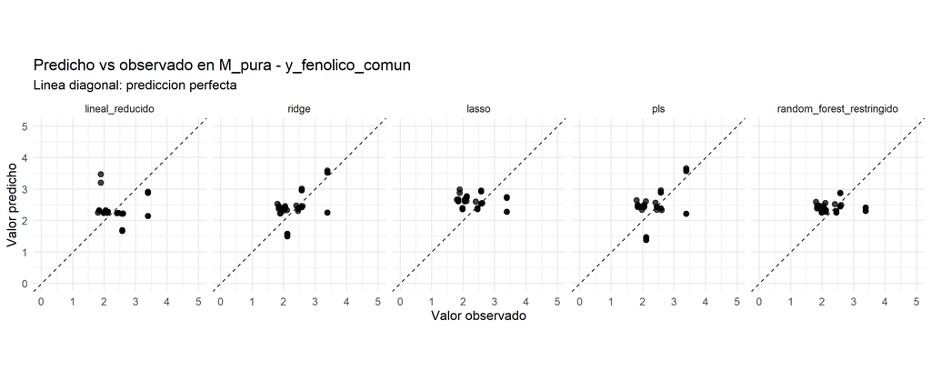

** 02_residuos_vs_predicho_M_pura_y_fenolico **

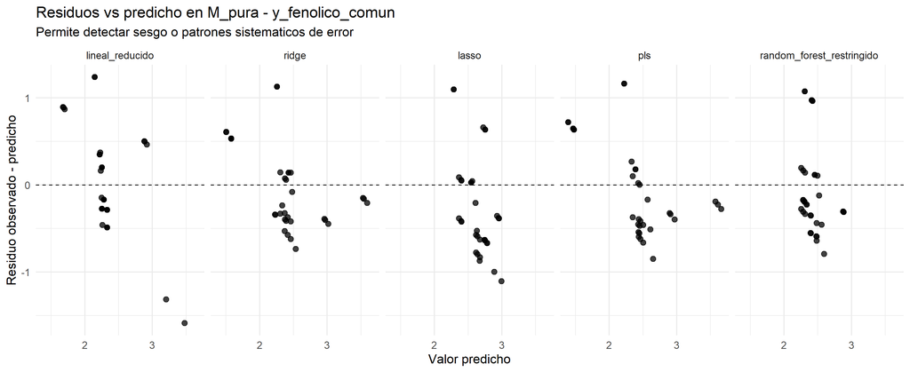

** 03_qqplot_residuos_M_pura_y_fenolico **

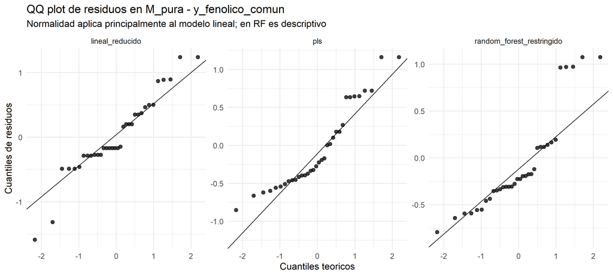

** 04_distribucion_residuos_y_fenolico **

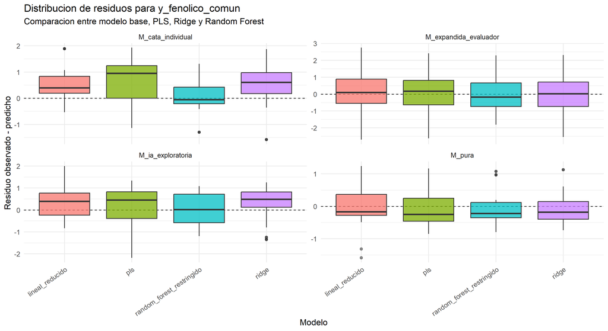

| escenario | target | modelo | es_outlier_eda | n_predicciones | n_atipicos_residual | pct_atipicos_residual | residuo_abs_medio | lectura |
| --- | --- | --- | --- | --- | --- | --- | --- | --- |
| M_cata_individual | y_fenolico_comun | elastic_net | TRUE | 10 | 1 | 10.0 | 0.7478 | Unidades ya marcadas como atipicas en el EDA quimico (T2/Q/Dixon) antes de modelar. |
| M_cata_individual | y_fenolico_comun | elastic_net | FALSE | 42 | 3 | 7.1 | 0.8463 | Unidades sin marca de atipico en el EDA quimico. |
| M_cata_individual | y_fenolico_comun | gradient_boosting_restringido | TRUE | 10 | 0 | 0.0 | 0.6299 | Unidades ya marcadas como atipicas en el EDA quimico (T2/Q/Dixon) antes de modelar. |
| M_cata_individual | y_fenolico_comun | gradient_boosting_restringido | FALSE | 42 | 0 | 0.0 | 0.9493 | Unidades sin marca de atipico en el EDA quimico. |
| M_cata_individual | y_fenolico_comun | lasso | TRUE | 10 | 0 | 0.0 | 0.6127 | Unidades ya marcadas como atipicas en el EDA quimico (T2/Q/Dixon) antes de modelar. |
| M_cata_individual | y_fenolico_comun | lasso | FALSE | 42 | 3 | 7.1 | 0.7504 | Unidades sin marca de atipico en el EDA quimico. |
| M_cata_individual | y_fenolico_comun | lineal_reducido | TRUE | 10 | 0 | 0.0 | 0.3772 | Unidades ya marcadas como atipicas en el EDA quimico (T2/Q/Dixon) antes de modelar. |
| M_cata_individual | y_fenolico_comun | lineal_reducido | FALSE | 42 | 5 | 11.9 | 0.6261 | Unidades sin marca de atipico en el EDA quimico. |
| M_cata_individual | y_fenolico_comun | media_entrenamiento | TRUE | 10 | 0 | 0.0 | 0.7092 | Unidades ya marcadas como atipicas en el EDA quimico (T2/Q/Dixon) antes de modelar. |
| M_cata_individual | y_fenolico_comun | media_entrenamiento | FALSE | 42 | 0 | 0.0 | 0.9969 | Unidades sin marca de atipico en el EDA quimico. |
| M_cata_individual | y_fenolico_comun | pls | TRUE | 10 | 0 | 0.0 | 0.6546 | Unidades ya marcadas como atipicas en el EDA quimico (T2/Q/Dixon) antes de modelar. |
| M_cata_individual | y_fenolico_comun | pls | FALSE | 42 | 3 | 7.1 | 0.8725 | Unidades sin marca de atipico en el EDA quimico. |
| M_cata_individual | y_fenolico_comun | random_forest_restringido | TRUE | 10 | 0 | 0.0 | 0.2659 | Unidades ya marcadas como atipicas en el EDA quimico (T2/Q/Dixon) antes de modelar. |
| M_cata_individual | y_fenolico_comun | random_forest_restringido | FALSE | 42 | 5 | 11.9 | 0.4260 | Unidades sin marca de atipico en el EDA quimico. |
| M_cata_individual | y_fenolico_comun | ridge | TRUE | 10 | 0 | 0.0 | 0.4940 | Unidades ya marcadas como atipicas en el EDA quimico (T2/Q/Dixon) antes de modelar. |
| M_cata_individual | y_fenolico_comun | ridge | FALSE | 42 | 3 | 7.1 | 0.8067 | Unidades sin marca de atipico en el EDA quimico. |
| M_cata_individual | y_frutal_comun | elastic_net | TRUE | 1 | 0 | 0.0 | 0.4348 | Unidades ya marcadas como atipicas en el EDA quimico (T2/Q/Dixon) antes de modelar. |
| M_cata_individual | y_frutal_comun | elastic_net | FALSE | 12 | 0 | 0.0 | 0.3382 | Unidades sin marca de atipico en el EDA quimico. |
| M_cata_individual | y_frutal_comun | gradient_boosting_restringido | TRUE | 1 | 0 | 0.0 | 0.4397 | Unidades ya marcadas como atipicas en el EDA quimico (T2/Q/Dixon) antes de modelar. |
| M_cata_individual | y_frutal_comun | gradient_boosting_restringido | FALSE | 12 | 0 | 0.0 | 0.2889 | Unidades sin marca de atipico en el EDA quimico. |
| M_cata_individual | y_frutal_comun | lasso | TRUE | 1 | 0 | 0.0 | 0.4684 | Unidades ya marcadas como atipicas en el EDA quimico (T2/Q/Dixon) antes de modelar. |
| M_cata_individual | y_frutal_comun | lasso | FALSE | 12 | 0 | 0.0 | 0.3726 | Unidades sin marca de atipico en el EDA quimico. |
| M_cata_individual | y_frutal_comun | lineal_reducido | TRUE | 1 | 0 | 0.0 | 0.4710 | Unidades ya marcadas como atipicas en el EDA quimico (T2/Q/Dixon) antes de modelar. |
| M_cata_individual | y_frutal_comun | lineal_reducido | FALSE | 12 | 0 | 0.0 | 0.8583 | Unidades sin marca de atipico en el EDA quimico. |
| M_cata_individual | y_frutal_comun | media_entrenamiento | TRUE | 1 | 0 | 0.0 | 0.5278 | Unidades ya marcadas como atipicas en el EDA quimico (T2/Q/Dixon) antes de modelar. |
| M_cata_individual | y_frutal_comun | media_entrenamiento | FALSE | 12 | 0 | 0.0 | 0.2583 | Unidades sin marca de atipico en el EDA quimico. |
| M_cata_individual | y_frutal_comun | pls | TRUE | 1 | 0 | 0.0 | 0.4457 | Unidades ya marcadas como atipicas en el EDA quimico (T2/Q/Dixon) antes de modelar. |
| M_cata_individual | y_frutal_comun | pls | FALSE | 12 | 0 | 0.0 | 0.4786 | Unidades sin marca de atipico en el EDA quimico. |
| M_cata_individual | y_frutal_comun | random_forest_restringido | TRUE | 1 | 0 | 0.0 | 0.4258 | Unidades ya marcadas como atipicas en el EDA quimico (T2/Q/Dixon) antes de modelar. |
| M_cata_individual | y_frutal_comun | random_forest_restringido | FALSE | 12 | 0 | 0.0 | 0.2826 | Unidades sin marca de atipico en el EDA quimico. |

[output cut: 82 more lines]

## 4.6 Conclusión

Sobre la corrección de reproducibilidad: antes de la corrección, la semilla aleatoria usada para el bootstrap se fijaba una sola vez al inicio del script y se reutilizaba para todos los escenarios y targets en el orden en que el código los recorría, de modo que el resultado de un escenario dependía de cuántos números aleatorios ya se habían consumido en escenarios anteriores dentro de la misma corrida (dos corridas con los escenarios en distinto orden podían dar métricas bootstrap ligeramente distintas para el mismo escenario). La corrección fija una semilla determinística por combinación escenario-target (derivada de sus nombres, no del orden de ejecución), de modo que cada escenario-target produce siempre las mismas 100 muestras de bootstrap sin importar qué otros escenarios se hayan corrido antes. Tras la corrección se verificó que correr el pipeline completo dos veces produce exactamente las mismas métricas de resumen (MAE, RMSE, R², Spearman) para cada escenario-target, confirmando que el pipeline es ahora determinístico de extremo a extremo.

Las variables más coherentes y estables para explicar la calidad fenólica son los fenoles volátiles cuantificados por GC-FID (guaiacol, p-cresol, o-cresol y 4-etil-guaiacol), lo que es consistente con la química conocida del carácter ahumado/fenólico del whisky. El análisis de sensibilidad confirma que estos resultados no dependen críticamente de un pequeño número de observaciones atípicas: el desempeño del modelo se mantiene comparable al excluir las unidades marcadas como atípicas en la etapa exploratoria. Tampoco dependen críticamente de las variables GC-MS, que tienen cobertura real baja (23.5%) dentro de `M_pura`: excluirlas por completo cambia el MAE bootstrap de Random Forest restringido en menos de un 2%.

La comparación entre escenarios aporta un hallazgo metodológico relevante: al agregar la cata individual JU a la matriz pura (`M_cata_individual`), el desempeño del modelo sube notoriamente (R² cercano al que se observaba antes de excluir JU por error). Esto confirma que gran parte de la señal “fácil” de versiones anteriores del análisis provenía específicamente de la cata de un solo evaluador, más fácil de predecir que el promedio de un panel — y refuerza que la exclusión de JU de la matriz principal fue la decisión metodológicamente correcta, no una pérdida de información sino una corrección de rigor.

En conjunto, la evidencia respalda que la calidad fenólica del whisky chileno estudiado está asociada de forma identificable y razonablemente estable a un grupo acotado de compuestos fenólicos volátiles, en un contexto donde el tamaño muestral impone límites claros a la magnitud de las conclusiones: este estudio se entiende como exploratorio / prueba de concepto, no como un modelo predictivo listo para uso industrial.